# Assignment_5

Andrew Shenal

2025-11-22

```r
# Package Set-Up
library(stats)
library(cluster)
library(mclust)
set.seed(111)

# Load data
df <- read.csv("./Cereals.csv")

# Make the cereal name the row names and remove the non-numerical columns for normalization
row.names(df) <- df[,1]
df <- df[,-(1:3)]

# Remove missing values and Scale data
df <- na.omit(df)
df <- scale(df)
```

1. Apply hierarchical clustering to the data using Euclidean distance to the normalized measurements. Use Agnes to compare the clustering from single linkage, complete linkage, average linkage, and Ward. Choose the best method.

```r
# Compute euclidean distance on the normalized data
d <- dist(df, method = "euclidean")

# Use agnes to apply the 4 clustering structures
hc_single <- agnes(d, method = "single")
hc_complete <- agnes(d, method = "complete")
hc_average <- agnes(d, method = "average")
hc_ward <- agnes(df, method = "ward")

# Compare Agglomerative coefficients
print(hc_single$ac) # 0.6067859
```

```
## [1] 0.6067859
```

```r
print(hc_complete$ac) # 0.8353712
```

```
## [1] 0.8353712
```

```r
print(hc_average$ac) # 0.7766075
```

```
## [1] 0.7766075
```

```r
print(hc_ward$ac) # 0.9046042 - Highest and best option
```

```
## [1] 0.9046042
```

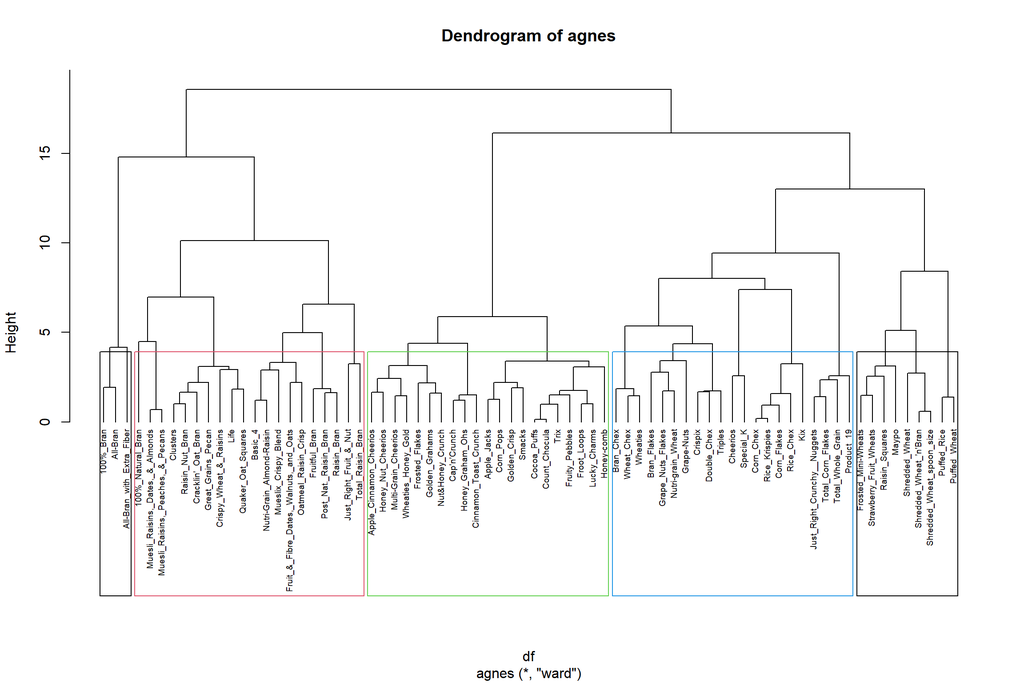

```r
pltree(hc_ward, cex = 0.6, hang = -1, main = "Dendrogram of agnes")
rect.hclust(hc_ward, k = 5, border = 1:4)
```

- I would choose around 5 clusters. A larger number of clusters would have weaker differences and reduce the ability to identify differences while a smaller number would bring too many distinct clusters together. At around 5 the clusters have enough distance between them to show that they are different with clear identifiable separation.

Comment on the structure of the clusters and on their stability. Hint: To check stability, partition the data and see how well clusters formed based on one part apply to the other part. To do this: ● Cluster partition A ● Use the cluster centroids from A to assign each record in partition B (each record is assigned to the cluster with the closest centroid). ● Assess how consistent the cluster assignments are compared to the assignments based on all the data.

```r
library(caret)
library(mclust)

set.seed(111)

# split data
idx <- createDataPartition(1:nrow(df), p = 0.7, list = FALSE)
train <- df[idx, ]
test <- df[-idx, ]

# hierarchical clustering on training set
d_train <- dist(train)
hc_train <- agnes(d_train, method = "ward")
cl_train <- cutree(hc_train, k = 5)

# compute centroids for training clusters
centroids <- aggregate(train, list(cl_train), mean)
centroids <- centroids[,-1]

# distance from each test row to each centroid
dist_to_cent <- matrix(NA, nrow = nrow(test), ncol = nrow(centroids))
for (i in 1:nrow(centroids)) {
  dist_to_cent[, i] <- rowSums((test - centroids[i, ])^2)
}

pred_test <- apply(dist_to_cent, 1, which.min)

# clustering test set directly
d_test <- dist(test)
hc_test <- agnes(d_test, method = "ward")
true_test <- cutree(hc_test, k = 5)

# stability
adjustedRandIndex(pred_test, true_test)
```

```
## [1] 0
```

After splitting the data and then testing the assignments, there is an ARI of 0 which indicates that the clusters are formed no better than random chance. I believe though that this is due to my method of splitting and testing the data as the full data method earlier shows clear differences between clusters.

Based on the results from the previous dendrogram, the red left cluster that contains cereals such as 100% natural bran, raisin nut bran, and great grains would be best for a healthy rotation of cereals. The cluster contains enough cereals for variety and contains cereals that have higher than average fiber and protein with lower than average sugar.

Also, to obtain this information normalization is required. Columns such as calories contain a very high range compared to protein which is much smaller. Without normalization, the columns similar to calories would skew the data.